# propcsddd – EU Omnibus Briefing

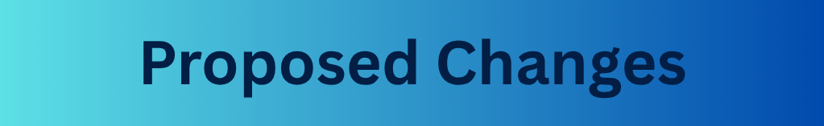

## **Corporate Sustainability Due Diligence Directive(CSDDD):**

Proposals to change the CSDDD do not include changes in scope but rather removing the required reporting from indirect suppliers unless there is a clear indication of harm. This change aims to shield SMEs from what information can be required from suppliers and value chains.

Proposed Effects of EU Omnibus Package on Standards Set by the CSDDD (2024/1760)

Harmonization

- Expanded harmonization of due diligence rules across the EU, especially for impact identification, remediation, and complaints mechanisms
- Member States can still go beyond in areas like labor law, where EU competence is limited

Stakeholder Definition

Stakeholders now limited to:

- Workers and their representatives
- Individuals and communities directly affected by a company or its direct business partners

Focus on Direct Business Partners

- Due diligence is now limited to direct business partners, unless credible evidence suggests harm deeper in the value chain
- Indirect partners only investigated under specific conditions (complaints, known past harm, media reports, etc.)

Mandatory Termination of Relationships

- Termination is no longer mandatory even when there is evidence of serious harm
- Companies may instead suspend the relationship and attempt remediation

Less Frequent Monitoring

- Companies now required to assess due diligence effectiveness every five years (instead of every year), unless urgent issues arise